# Lab Assignment Four: Multi-Layer Perceptron

*Yiwen Xu, Kehan Zhang, Shuang Liang, Christopher Deng Jr*

## 1. Load, Split, and Balance

### 1.1 Load Data

```python
import pandas as pd
import numpy as np
import matplotlib
import matplotlib.pyplot as plt
import warnings
warnings.filterwarnings('ignore')
np.random.seed(1)
```

Data is gathered from: https://www.kaggle.com/muonneutrino/us-census-demographic-data/data

```python
df = pd.read_csv("acs2017_census_tract_data.csv")
df.head()
```

|  | TractId | State | County | TotalPop | Men | Women | Hispanic | White | Black | Native | ... | Walk | OtherTransp | WorkAtHome | MeanCommute | Employed | PrivateWork | PublicWork | SelfEmployed | FamilyWork | Unemployment |
| --- | --- | --- | --- | --- | --- | --- | --- | --- | --- | --- | --- | --- | --- | --- | --- | --- | --- | --- | --- | --- | --- |
| 0 | 1001020100 | Alabama | Autauga County | 1845 | 899 | 946 | 2.4 | 86.3 | 5.2 | 0.0 | ... | 0.5 | 0.0 | 2.1 | 24.5 | 881 | 74.2 | 21.2 | 4.5 | 0.0 | 4.6 |
| 1 | 1001020200 | Alabama | Autauga County | 2172 | 1167 | 1005 | 1.1 | 41.6 | 54.5 | 0.0 | ... | 0.0 | 0.5 | 0.0 | 22.2 | 852 | 75.9 | 15.0 | 9.0 | 0.0 | 3.4 |
| 2 | 1001020300 | Alabama | Autauga County | 3385 | 1533 | 1852 | 8.0 | 61.4 | 26.5 | 0.6 | ... | 1.0 | 0.8 | 1.5 | 23.1 | 1482 | 73.3 | 21.1 | 4.8 | 0.7 | 4.7 |
| 3 | 1001020400 | Alabama | Autauga County | 4267 | 2001 | 2266 | 9.6 | 80.3 | 7.1 | 0.5 | ... | 1.5 | 2.9 | 2.1 | 25.9 | 1849 | 75.8 | 19.7 | 4.5 | 0.0 | 6.1 |
| 4 | 1001020500 | Alabama | Autauga County | 9965 | 5054 | 4911 | 0.9 | 77.5 | 16.4 | 0.0 | ... | 0.8 | 0.3 | 0.7 | 21.0 | 4787 | 71.4 | 24.1 | 4.5 | 0.0 | 2.3 |

5 rows × 37 columns

```python
df.describe()
```

|  | TractId | TotalPop | Men | Women | Hispanic | White | Black | Native | Asian | Pacific | ... | Walk | OtherTransp | WorkAtHome | MeanCommute | Employed | PrivateWork | PublicWork | SelfEmployed | FamilyWork | Unemployment |
| --- | --- | --- | --- | --- | --- | --- | --- | --- | --- | --- | --- | --- | --- | --- | --- | --- | --- | --- | --- | --- | --- |
| count | 7.400100e+04 | 74001.000000 | 74001.000000 | 74001.000000 | 73305.000000 | 73305.000000 | 73305.00000 | 73305.000000 | 73305.000000 | 73305.000000 | ... | 73200.000000 | 73200.000000 | 73200.000000 | 73055.000000 | 74001.000000 | 73190.000000 | 73190.000000 | 73190.000000 | 73190.000000 | 73191.000000 |
| mean | 2.839113e+10 | 4384.716017 | 2157.710707 | 2227.005311 | 17.265444 | 61.309043 | 13.28910 | 0.734047 | 4.753691 | 0.147341 | ... | 3.042825 | 1.894605 | 4.661466 | 26.056594 | 2049.152052 | 79.494222 | 14.163342 | 6.171484 | 0.171164 | 7.246738 |
| std | 1.647593e+10 | 2228.936729 | 1120.560504 | 1146.240218 | 23.073811 | 30.634461 | 21.60118 | 4.554247 | 8.999888 | 1.029250 | ... | 5.805753 | 2.549374 | 4.014940 | 7.124524 | 1138.865457 | 8.126383 | 7.328680 | 3.932364 | 0.456580 | 5.227624 |
| min | 1.001020e+09 | 0.000000 | 0.000000 | 0.000000 | 0.000000 | 0.000000 | 0.00000 | 0.000000 | 0.000000 | 0.000000 | ... | 0.000000 | 0.000000 | 0.000000 | 1.000000 | 0.000000 | 0.000000 | 0.000000 | 0.000000 | 0.000000 | 0.000000 |
| 25% | 1.303901e+10 | 2903.000000 | 1416.000000 | 1465.000000 | 2.600000 | 38.000000 | 0.80000 | 0.000000 | 0.200000 | 0.000000 | ... | 0.400000 | 0.400000 | 2.000000 | 21.100000 | 1276.000000 | 75.200000 | 9.300000 | 3.500000 | 0.000000 | 3.900000 |
| 50% | 2.804700e+10 | 4105.000000 | 2007.000000 | 2082.000000 | 7.400000 | 70.400000 | 3.80000 | 0.000000 | 1.500000 | 0.000000 | ... | 1.400000 | 1.200000 | 3.800000 | 25.400000 | 1895.000000 | 80.600000 | 13.000000 | 5.500000 | 0.000000 | 6.000000 |
| 75% | 4.200341e+10 | 5506.000000 | 2707.000000 | 2803.000000 | 21.100000 | 87.700000 | 14.60000 | 0.400000 | 5.000000 | 0.000000 | ... | 3.300000 | 2.500000 | 6.300000 | 30.300000 | 2635.000000 | 85.000000 | 17.600000 | 8.000000 | 0.000000 | 9.000000 |
| max | 7.215375e+10 | 65528.000000 | 32266.000000 | 33262.000000 | 100.000000 | 100.000000 | 100.00000 | 100.000000 | 100.000000 | 71.900000 | ... | 100.000000 | 100.000000 | 100.000000 | 73.900000 | 28945.000000 | 100.000000 | 100.000000 | 100.000000 | 22.300000 | 100.000000 |

8 rows × 35 columns

```python
df.info()
```

```
<class 'pandas.core.frame.DataFrame'>
RangeIndex: 74001 entries, 0 to 74000
Data columns (total 37 columns):
 #   Column            Non-Null Count  Dtype
---  ------            --------------  -----
 0   TractId           74001 non-null  int64
 1   State             74001 non-null  object
 2   County            74001 non-null  object
 3   TotalPop          74001 non-null  int64
 4   Men               74001 non-null  int64
 5   Women             74001 non-null  int64
 6   Hispanic          73305 non-null  float64
 7   White             73305 non-null  float64
 8   Black             73305 non-null  float64
 9   Native            73305 non-null  float64
```

[output cut: 29 more lines]

In the original dataset, states are strings. We encoded them to integers ranging from 0 to 51.

```python
df['State'].unique()
```

```
array(['Alabama', 'Alaska', 'Arizona', 'Arkansas', 'California',
       'Colorado', 'Connecticut', 'Delaware', 'District of Columbia',
       'Florida', 'Georgia', 'Hawaii', 'Idaho', 'Illinois', 'Indiana',
       'Iowa', 'Kansas', 'Kentucky', 'Louisiana', 'Maine', 'Maryland',
       'Massachusetts', 'Michigan', 'Minnesota', 'Mississippi',
       'Missouri', 'Montana', 'Nebraska', 'Nevada', 'New Hampshire',
       'New Jersey', 'New Mexico', 'New York', 'North Carolina',
       'North Dakota', 'Ohio', 'Oklahoma', 'Oregon', 'Pennsylvania',
       'Rhode Island', 'South Carolina', 'South Dakota', 'Tennessee',
       'Texas', 'Utah', 'Vermont', 'Virginia', 'Washington',
       'West Virginia', 'Wisconsin', 'Wyoming', 'Puerto Rico'],
      dtype=object)
```

```python
from sklearn import preprocessing

# label_encoder object knows how to understand word labels.
label_encoder = preprocessing.LabelEncoder()

# Encode labels in column 'species'.
df['State']= label_encoder.fit_transform(df['State'])

df['State'].unique()
```

```
array([ 0,  1,  2,  3,  4,  5,  6,  7,  8,  9, 10, 11, 12, 13, 14, 15, 16,
       17, 18, 19, 20, 21, 22, 23, 24, 25, 26, 27, 28, 29, 30, 31, 32, 33,
       34, 35, 36, 37, 38, 40, 41, 42, 43, 44, 45, 46, 47, 48, 49, 50, 51,
       39])
```

Remove column TractId and County. Type of County in the dataset is string data with 1955 unique values which is a large number. It will be memory comsuming if we keep this variable and one hot encode later. Therefore, we choose to drop column County.

```python
len(df['County'].unique())
```

```
1955
```

```python
df = df.drop(['TractId', 'County'], axis= 1)
df.info()
```

```
<class 'pandas.core.frame.DataFrame'>
RangeIndex: 74001 entries, 0 to 74000
Data columns (total 35 columns):
 #   Column            Non-Null Count  Dtype
---  ------            --------------  -----
 0   State             74001 non-null  int32
 1   TotalPop          74001 non-null  int64
 2   Men               74001 non-null  int64
 3   Women             74001 non-null  int64
 4   Hispanic          73305 non-null  float64
 5   White             73305 non-null  float64
 6   Black             73305 non-null  float64
 7   Native            73305 non-null  float64
 8   Asian             73305 non-null  float64
 9   Pacific           73305 non-null  float64
```

[output cut: 27 more lines]

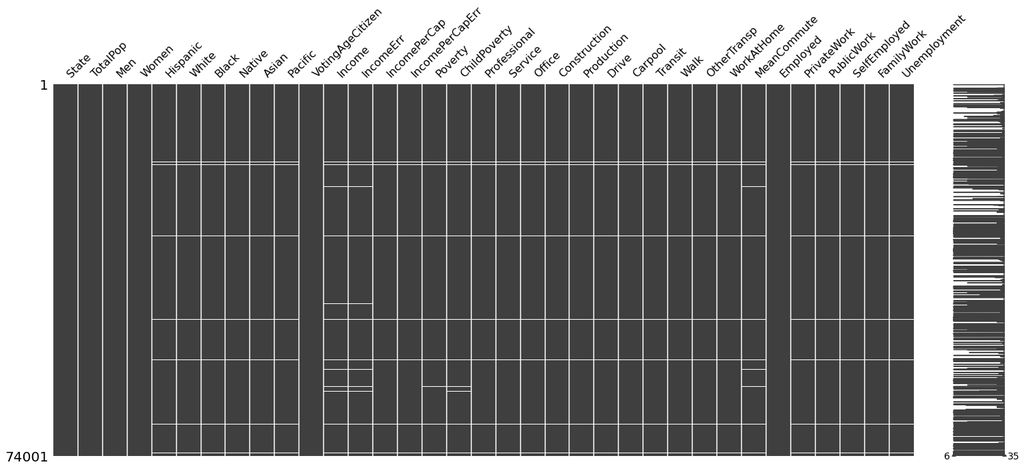

```python
import missingno as mn

mn.matrix(df)
```

Remove rows with missing data

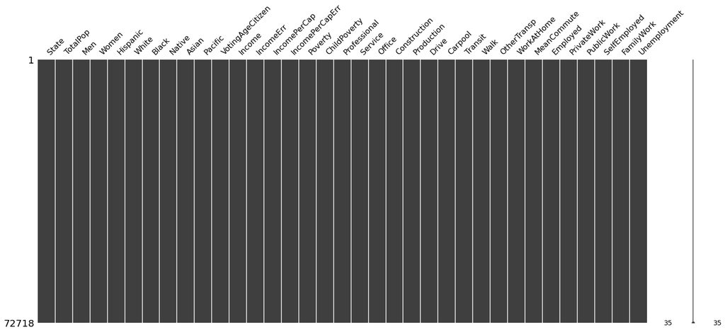

```python
# remove rows with missing data
df = df.dropna()

mn.matrix(df)
```

### 1.2 Split and Balance Dataset

```python
df['ChildPoverty'].describe()
```

```
count    72718.000000
mean        21.148476
std         18.572714
min          0.000000
25%          6.200000
50%         16.300000
75%         31.600000
max        100.000000
Name: ChildPoverty, dtype: float64
```

```
[ 6.2 16.3 31.6]
```

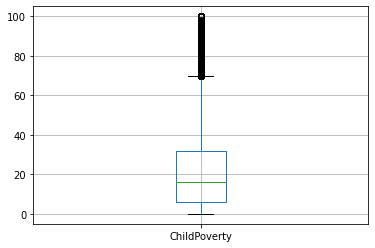

```python
ax = df.boxplot(column = 'ChildPoverty')
print(np.percentile(df["ChildPoverty"], [25, 50, 75]))
```

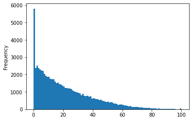

```python
df['ChildPoverty'].plot.hist(bins = 100)
plt.show()
```

```python
from sklearn.model_selection import train_test_split

target_var_name = 'ChildPoverty'

y = df['ChildPoverty']
# y = pd.cut(y, [-1,10,20.2,24.9,100], labels = [0,1,2,3])
y = pd.cut(y, [-1,8.1,16.9,27.7,100], labels = [0,1,2,3])
X = df.drop(columns = 'ChildPoverty')


X_train, X_test, y_train, y_test = train_test_split(X, y, test_size=0.2, random_state=42)
```

```python
print('train:', y_train.shape[0]/y.shape[0])
print('test:', y_test.shape[0]/y.shape[0])
```

```
train: 0.7999944992986606
test: 0.20000550070133943
```

Show the distribution of classes of current dataset

```python
print("class 1 is : ",len(y_train[y_train == 0])/len(y_train))
print("class 2 is : ", (len(y_train[y_train == 1]))/len(y_train))
print("class 3 is : ", (len(y_train[y_train == 2]))/len(y_train))
print("class 4 is : ", len(y_train[y_train == 3])/len(y_train))
```

```
class 1 is :  0.3049816069034276
class 2 is :  0.20705126001306426
class 3 is :  0.1858562244301578
class 4 is :  0.3021109086533503
```

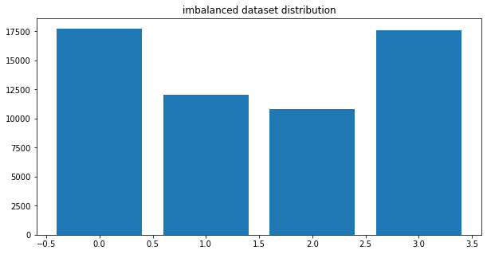

```python
num = []

for i in range(4):
    l = len(y_train[y_train==i])
    num.append(l)

fig = plt.figure(figsize=(10,5))
plt.bar(range(4),num)
plt.title('imbalanced dataset distribution')
plt.show()
```

We can see that the current distribution is imbalanced. We use SMOTE to balance the training dataset. We are not balancing the test dataset because we can't expect the data to be balanced when deploying the model in the real world. If we were to balance the test dataset, we won't get the accurate performance of the model.

```python
# pip install imblearn
from imblearn.over_sampling import SMOTE
from collections import Counter

oversample = SMOTE()
X_train, y_train = oversample.fit_resample(X_train, y_train)
distribution = Counter(y_train)
distribution
```

```
Counter({0: 17742, 3: 17742, 2: 17742, 1: 17742})
```

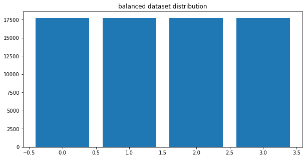

```python
num = []

for i in range(4):
    l = len(y_train[y_train==i])
    num.append(l)

fig = plt.figure(figsize=(10,5))
plt.bar(range(4),num)
plt.title('balanced dataset distribution')
plt.show()
```

## 2. Pre-processing and Initial Modeling

```python
import numpy as np
from scipy.special import expit
import sys
import pandas as pd

class TwoLayerPerceptronBase(object):
    def __init__(self, n_hidden=30,
                 C=0.0, epochs=500, eta=0.001, random_state=None):
        np.random.seed(random_state)
        self.n_hidden = n_hidden
        self.l2_C = C
        self.epochs = epochs
        self.eta = eta


    @staticmethod
    def _encode_labels(y):
        """Encode labels into one-hot representation"""
        onehot = pd.get_dummies(y).values.T

        return onehot


    def _initialize_weights(self):
        """Initialize weights with small random numbers."""
        W1_num_elems = (self.n_features_)*self.n_hidden
        W1 = np.random.uniform(-1.0, 1.0, size=W1_num_elems)
        W1 = W1.reshape(self.n_hidden, self.n_features_) # reshape to be W
        b1 = np.zeros((self.n_hidden, 1))

        W2_num_elems = (self.n_hidden)*self.n_output_
        W2 = np.random.uniform(-1.0, 1.0, size=W2_num_elems)
        W2 = W2.reshape(self.n_output_, self.n_hidden)
        b2 = np.zeros((self.n_output_, 1))

        return W1, W2, b1, b2


    @staticmethod
    def _sigmoid(z):
        """Use scipy.special.expit to avoid overflow"""
        # 1.0 / (1.0 + np.exp(-z))
        return expit(z)


    @staticmethod
    def _L2_reg(lambda_, W1, W2):
        """Compute L2-regularization cost"""
        # only compute for non-bias terms
        return (lambda_) * np.sqrt(np.mean(W1[:, 1:] ** 2) + np.mean(W2[:, 1:] ** 2))


    def _cost(self,A3,Y_enc,W1,W2):
        '''Get the objective function value'''
        cost = np.mean((Y_enc-A3)**2)
        L2_term = self._L2_reg(self.l2_C, W1, W2)
        return cost + L2_term
```

```python
class TwoLayerPerceptron(TwoLayerPerceptronBase):
    def __init__(self, n_hidden=30,
                 C=0.0, epochs=100, eta=0.001, random_state=None,
                 alpha=0.1, decrease_const=0.0, shuffle=True, minibatches=1):
        np.random.seed(random_state)
        self.n_hidden = n_hidden
        self.l2_C = C
        self.epochs = epochs
        self.eta = eta

        self.alpha = alpha
        self.decrease_const = decrease_const
        self.shuffle = shuffle
        self.minibatches = minibatches


    def _initialize_weights(self):
        """Initialize weights Glorot and He normalization."""
        init_bound = 4*np.sqrt(6. / (self.n_hidden + self.n_features_ + 1))
        W1 = np.random.uniform(-init_bound, init_bound,(self.n_hidden, self.n_features_ + 1))
        W1[:,:1] = 0

        # reduce the final layer magnitude in order to balance the size of the gradients
        # between
        init_bound = 4*np.sqrt(6 / (self.n_output_ + self.n_hidden + 1))
        W2 = np.random.uniform(-init_bound, init_bound,(self.n_output_, self.n_hidden + 1))
        W2[:,:1] = 0

        return W1, W2


    @staticmethod
    def _add_bias_unit(X, how='column'):
        """Add bias unit (column or row of 1s) to array at index 0"""
        if how == 'column':
            ones = np.ones((X.shape[0], 1))
            X_new = np.hstack((ones, X))
        elif how == 'row':
            ones = np.ones((1, X.shape[1]))
            X_new = np.vstack((ones, X))
        return X_new


    def _get_gradient(self, A1, A2, A3, Z1, Z2, Y_enc, W1, W2):
        """ Compute gradient step using backpropagation.
        """
        # vectorized backpropagation
        V2 = (A3-Y_enc) # <- this is only line that changed
        V1 = A2*(1-A2)*(W2.T @ V2)

        grad2 = V2 @ A2.T
        grad1 = V1[1:,:] @ A1.T

        # regularize weights that are not bias terms
        grad1[:, 1:] += W1[:, 1:] * self.l2_C
        grad2[:, 1:] += W2[:, 1:] * self.l2_C

        return grad1, grad2


    def _feedforward(self, X, W1, W2):
        """Compute feedforward step
        -----------
        X : Input layer with original features.
        W1: Weight matrix for input layer -> hidden layer.
        W2: Weight matrix for hidden layer -> output layer.
        ----------
        a1-a3 : activations into layer (or output layer)
        z1-z2 : layer inputs

        """
        A1 = self._add_bias_unit(X.T, how='row')
        Z1 = W1 @ A1
        A2 = self._sigmoid(Z1)
        A2 = self._add_bias_unit(A2, how='row')
        Z2 = W2 @ A2
        A3 = self._sigmoid(Z2)
        return A1, Z1, A2, Z2, A3


    def fit(self, X, y, print_progress=False, XY_test=None):
        """ Learn weights from training data. With mini-batch"""
        X_data, y_data = X.copy(), y.copy()
        Y_enc = self._encode_labels(y)

        # init weights and setup matrices
        self.n_features_ = X_data.shape[1]
        self.n_output_ = Y_enc.shape[0]
        self.W1, self.W2 = self._initialize_weights()


        self.cost_ = []
        self.score_ = []
        # get starting acc
        self.score_.append(accuracy_score(y_data,self.predict(X_data)))
        # keep track of validation, if given
        if XY_test is not None:
            X_test = XY_test[0].copy()
            y_test = XY_test[1].copy()
            self.val_score_ = []
            self.val_score_.append(accuracy_score(y_test,self.predict(X_test)))

        for i in range(self.epochs):


            if print_progress>0 and (i+1)%print_progress==0:
                sys.stderr.write('\rEpoch: %d/%d' % (i+1, self.epochs))
                sys.stderr.flush()

            if self.shuffle:
                idx_shuffle = np.random.permutation(y_data.shape[0])
                X_data, Y_enc, y_data = X_data[idx_shuffle], Y_enc[:, idx_shuffle], y_data[idx_shuffle]

            mini = np.array_split(range(y_data.shape[0]), self.minibatches)
            mini_cost = []
            for idx in mini:

                # feedforward
                A1, Z1, A2, Z2, A3 = self._feedforward(X_data[idx],
                                                       self.W1,
                                                       self.W2)

                cost = self._cost(A3,Y_enc[:, idx],self.W1,self.W2)
                mini_cost.append(cost) # this appends cost of mini-batch only

                # compute gradient via backpropagation
                grad1, grad2 = self._get_gradient(A1=A1, A2=A2, A3=A3, Z1=Z1, Z2=Z2,
                                                  Y_enc=Y_enc[:, idx],
                                                  W1=self.W1,W2=self.W2)
                self.W1 -= self.eta * grad1
                self.W2 -= self.eta * grad2

            self.cost_.append(mini_cost)
            self.score_.append(accuracy_score(y_data,self.predict(X_data)))
            if XY_test is not None:
                self.val_score_.append(accuracy_score(y_test,self.predict(X_test)))

        return self


    def _cost(self,A3,Y_enc,W1,W2):
        '''Get the objective function value'''
        cost = -np.mean(np.nan_to_num((Y_enc*np.log(A3)+(1-Y_enc)*np.log(1-A3))))
        L2_term = self._L2_reg(self.l2_C, W1, W2)
        return cost + L2_term


    def predict(self, X):
        """Predict class labels"""
        _, _, _, _, A3 = self._feedforward(X, self.W1, self.W2)
        y_pred = np.argmax(A3, axis=0)
        return y_pred
```

```python
from sklearn.metrics import accuracy_score
import matplotlib.pyplot as plt
%matplotlib inline

def cost_epochs(nn):
    # take the mean of each minibatch epoch
    cost_avgs = [np.mean(x) for x in nn.cost_]

    plt.plot(range(len(cost_avgs)), cost_avgs, color='red')
    plt.ylabel('Cost')
    plt.xlabel('Epochs')
    plt.tight_layout()
    plt.show()
```

### 2.1 Use the example two-layer perceptron network from the class example and quantify performance using accuracy.

```python
from sklearn.metrics import accuracy_score
from sklearn.metrics import mean_squared_error
```

```python
params = dict(n_hidden=50,
              C=0.1, # tradeoff L2 regularizer
              epochs=200, # iterations
              eta=0.001,  # learning rate
              minibatches=len(X_train)/32, # minibatch size
              shuffle=True,
              random_state=1)
```

```python
%%time
nn = TwoLayerPerceptron(**params)
nn.fit(X_train.to_numpy(), y_train.to_numpy(), print_progress=10)
yhat = nn.predict(X_test.to_numpy())
accuracy_model1 = accuracy_score(y_test.to_numpy(),yhat)
print('Accuracy:',accuracy_model1)
```

```
Epoch: 200/200
```

```
Accuracy: 0.21142739273927394
CPU times: total: 16min 6s
Wall time: 2min 2s
```

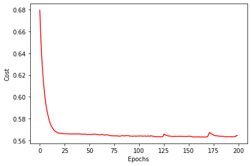

```python
cost_epochs(nn)
```

### 2.2 Normalize the continuous numeric feature data

```python
from sklearn.preprocessing import StandardScaler
scaler = StandardScaler()

norm_features = [col for col in X_train.columns if col != 'State']

X_train[norm_features] = scaler.fit_transform(X_train[norm_features])
X_test[norm_features] = scaler.fit_transform(X_test[norm_features])
```

```python
%%time
nn_norm = TwoLayerPerceptron(**params)
nn_norm.fit(X_train.to_numpy(), y_train.to_numpy(), print_progress=10)
yhat_norm = nn_norm.predict(X_test.to_numpy())
accuracy_model2 = accuracy_score(y_test.to_numpy(),yhat_norm)
print('Accuracy:',accuracy_model2)
```

```
Epoch: 200/200
```

```
Accuracy: 0.684474697469747
CPU times: total: 13min 20s
Wall time: 1min 40s
```

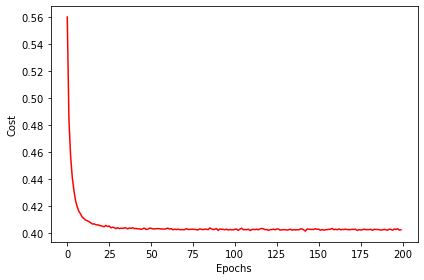

```python
cost_epochs(nn_norm)
```

### 2.3 Normalize the continuous numeric feature data and one hot encode the categorical data

```python
onehotencode = pd.get_dummies(X_train['State'])
X_train = X_train.drop(['State'],axis = 1)
X_train = pd.concat([onehotencode, X_train], axis=1)

onehotencode = pd.get_dummies(X_test['State'])
X_test = X_test.drop(['State'],axis = 1)
X_test= pd.concat([onehotencode, X_test], axis=1)
```

```python
%%time
nn_norm_encode = TwoLayerPerceptron(**params)
nn_norm_encode.fit(X_train.to_numpy(), y_train.to_numpy(), print_progress=10)
yhat_norm_encode = nn_norm_encode.predict(X_test.to_numpy())
accuracy_model3 = accuracy_score(y_test.to_numpy(),yhat_norm_encode)
print('Accuracy:',accuracy_model3)
```

```
Epoch: 200/200
```

```
Accuracy: 0.7030390539053906
CPU times: total: 15min
Wall time: 1min 53s
```

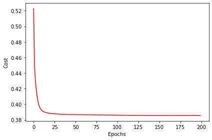

```python
cost_epochs(nn_norm_encode)
```

### 2.4 Compare the performance of the three models

```python
def create_contingency_McNemar(y_test, model1_pred, model2_pred):

    correct1_correct2 = 0  # model 1 predict correctly, model 2 also predict correctly
    correct1_wrong2 = 0 # model 1 predict correctly, model 2 predict wrong
    wrong1_correct2 = 0
    wrong1_wrong2 = 0
    table = np.zeros([2, 2],dtype = int)

    for i in range(len(y_test)):
        if model1_pred[i] == y_test[i] and model2_pred[i] == y_test[i]:
            correct1_correct2 +=1
        elif model1_pred[i] == y_test[i] and model2_pred[i] != y_test[i]:
            correct1_wrong2 +=1
        elif model1_pred[i] != y_test[i] and model2_pred[i] == y_test[i]:
            wrong1_correct2 +=1
        else:
            wrong1_wrong2 +=1
    table[0][0] = int(correct1_correct2)
    table[0][1] = int(correct1_wrong2)
    table[1][0] = int(wrong1_correct2)
    table[1][1] = int(wrong1_wrong2)

    return table
```

```python
from statsmodels.stats.contingency_tables import mcnemar

temp_table = create_contingency_McNemar(y_test.to_numpy(), yhat, yhat_norm)
result = mcnemar(temp_table, exact=True)

print('model 1 & model 2')
print('contingency_tables:')
print(temp_table)
print('caculate the McNemar')
print(result)
if result.pvalue < 0.05:
    print('Reject the Null hypothesis: Different proportions of errors.')
else:
    print('Take the Null hypothesis: Same proportions of errors.')
print('---------------------------------------------------')


temp_table = create_contingency_McNemar(y_test.to_numpy(), yhat, yhat_norm_encode)
result = mcnemar(temp_table, exact=True)

print('model 1 & model 3')
print('contingency_tables:')
print(temp_table)
print('caculate the McNemar')
print(result)
if result.pvalue < 0.05:
    print('Reject the Null hypothesis: Different proportions of errors.')
else:
    print('Take the Null hypothesis: Same proportions of errors.')
print('---------------------------------------------------')


temp_table = create_contingency_McNemar(y_test.to_numpy(), yhat_norm, yhat_norm_encode)
result = mcnemar(temp_table, exact=True)

print('model 2 & model 3')
print('contingency_tables:')
print(temp_table)
print('caculate the McNemar')
print(result)
if result.pvalue < 0.05:
    print('Reject the Null hypothesis: Different proportions of errors.')
else:
    print('Take the Null hypothesis: Same proportions of errors.')
print('---------------------------------------------------')
```

```
model 1 & model 2
contingency_tables:
[[1174 1901]
 [8781 2688]]
caculate the McNemar
pvalue      0.0
statistic   1901.0
Reject the Null hypothesis: Different proportions of errors.
---------------------------------------------------
model 1 & model 3
contingency_tables:
[[1538 1537]
 [8687 2782]]
caculate the McNemar
pvalue      0.0
statistic   1537.0
Reject the Null hypothesis: Different proportions of errors.
---------------------------------------------------
model 2 & model 3
contingency_tables:
[[8957  998]
 [1268 3321]]
caculate the McNemar
pvalue      1.5366303995521976e-08
statistic   998.0
Reject the Null hypothesis: Different proportions of errors.
---------------------------------------------------
```

Based on the result of McNemar testm, we can say that the performance between three models are significantly different since they all have different proportions of errors.

Model 1 and 2 are significantly different in performance, and accuracy of model 2 is higher than model 1. Therefore, we can say that model 2 has better performance than model 1. This is because normalization helps increase the accuracy of the model. Without normalization, data has very different ranges. This can cause a problem where variables with larger numbers having more weight in predicting the result, which affects the accuracy of the model. After normalization, each variable is given equal weights, which increase the accuracy of the model.

Model 2 and 3 are significantly different in performance, and accuracy of model 3 is higher than model 2. Therefore, we can say that model 3 has better performance than model 2. After one hot encoding the categorical data, we created additional features based on the number of unique values. This ensures that higher numbers won't have more weights in predicting the result, thus increase the accuracy of the model.

Model 1 and 3 are significantly different in performance, and accuracy of model 3 is much higher than model 1.

Therefore, we can say that model 3 has better performance than model 1. We can conclude that normalizing continuous numeric features and one hot encoding categorical data can increase accuracy of model.

## 3. Modeling

```python
# base classifier model for Multi-layer model

# start with a simple base classifier, which can't be fit or predicted
# it only has internal classes to be used by classes that will subclass it
class CustomMLPBase(object):
    def __init__(self, n_hiddens=[30],
                 C=0.0, epochs=500, eta=0.001, random_state=None):
        np.random.seed(random_state)
        self.n_hiddens = n_hiddens
        self.l2_C = C
        self.epochs = epochs
        self.eta = eta

    @staticmethod
    def _encode_labels(y):
        """Encode labels into one-hot representation"""
        onehot = pd.get_dummies(y).values.T

        return onehot

    @staticmethod
    def _sigmoid(z):
        """Use scipy.special.expit to avoid overflow"""
        # 1.0 / (1.0 + np.exp(-z))
        return expit(z)

    @staticmethod
    def _add_bias_unit(X, how='column'):
        """Add bias unit (column or row of 1s) to array at index 0"""
        if how == 'column':
            ones = np.ones((X.shape[0], 1))
            X_new = np.hstack((ones, X))
        elif how == 'row':
            ones = np.ones((1, X.shape[1]))
            X_new = np.vstack((ones, X))
        return X_new
```

```python
class MultiLayerPerceptron(CustomMLPBase):
    def __init__(self, alpha=0.0, decrease_const=0.0, shuffle=True,
                 minibatches=1, **kwds):
        self.alpha = alpha
        self.decrease_const = decrease_const
        self.shuffle = shuffle
        self.minibatches = minibatches

        super().__init__(**kwds)

    def _initialize_weights(self):
        layers = self.n_hiddens.copy()
        # reduce the final layer magnitude in order to balance the size of the gradients between
        layers.append(self.n_output_)
        W_list = []
        features = self.n_features_
        for idx, size_hidden in enumerate(layers):
            """Initialize weights Glorot and He normalization."""
            init_bound = 4 * np.sqrt(6. / (size_hidden + features + 1))
            W = np.random.uniform(-init_bound, init_bound, (size_hidden, features + 1))
            W[:,:1] = 0

            features = size_hidden
            W_list.append(W)
        return W_list

    @staticmethod
    def _L2_reg(lambda_, W_list):
        """Compute L2-regularization cost"""
        # only compute for non-bias terms
        weights = 0
        for W in W_list:
            weights += np.mean(W[:, 1:] ** 2)
        return (lambda_/2.0) * np.sqrt(weights)

    def _cost(self, output ,Y_enc, W_list):
        '''over write cost function'''
        cost = np.mean((Y_enc-output)**2)
        L2_term = self._L2_reg(self.l2_C, W_list)
        return cost + L2_term

    def _feedforward(self, X, W_list):
        """Compute feedforward step"""
        A_list = []
        Z_list = []
        for i, W in enumerate(W_list):
            if i == 0:
                A = self._add_bias_unit(X.T, how = 'row')
            else:
                A = self._sigmoid(Z)
                A = self._add_bias_unit(A, how = 'row')
            '''print("A.shape:",A.shape)
            print("W.shape:",W.shape)'''
            Z = W @ A
            A_list.append(A)
            Z_list.append(Z)
        A_output = self._sigmoid(Z)
        A_list.append(A_output)
        return A_list, Z_list

    def _get_gradient(self, A_list, Z_list, y, W_list):
        g_list = []
        A_last = A_list[-1]

        # vectorized backpropagation
        V_last = -2 * (y - A_last) * A_last * (1 - A_last)
        i = 1
        length = len(W_list)
        for A, W in zip(A_list[:-1][::-1], W_list[::-1]):
            if i == 1:
                grad = V_last @ A.T
                V = W.T @ V_last
            else:
                grad = V_last[1:,:] @ A.T
                if i != length:
                    V = (W.T @ V_last[1:,:])
            if length - 1 - i >= 0:
                V = A * (1 - A) * V
                V_last = V

            # regularize weights that are not bias terms
            grad[:,1:] += W[:,1:] * self.l2_C
            g_list.append(grad)
            i += 1
        return g_list[::-1]

    def fit(self, X, y, print_progress=False):
        """ Learn weights from training data. With mini-batch"""
        X_data, y_data = X.copy(), y.copy()
        Y_enc = self._encode_labels(y)

        # init weights and setup matrices
        self.n_features_ = X_data.shape[1]
        self.n_output_ = Y_enc.shape[0]
        self.W_list = self._initialize_weights()

        self.cost_ = []
        self.score_ = []
        self.score_.append(accuracy_score(y_data, self.predict(X_data)))

        len_layers = len(self.n_hiddens)
        self.grad_W_list = []

        for i in range(len_layers + 1):
            self.grad_W_list.append(np.zeros(self.epochs, dtype=float))

        for i in range(self.epochs):

            if print_progress>0 and (i+1)%print_progress==0:
                sys.stderr.write('\rEpoch: %d/%d' % (i+1, self.epochs))
                sys.stderr.flush()

            if self.shuffle:
                idx_shuffle = np.random.permutation(y_data.shape[0])
                X_data, Y_enc, y_data = X_data[idx_shuffle], Y_enc[:, idx_shuffle], y_data[idx_shuffle]

            mini = np.array_split(range(y_data.shape[0]), self.minibatches)
            mini_cost = []
            for j in mini:

                # feedforward
                A_list, Z_list = self._feedforward(X_data[j], self.W_list)
                cost = self._cost(A_list[-1], Y_enc[:, j], self.W_list)
                mini_cost.append(cost) # this appends cost of mini-batch only

                # compute gradient via backpropagation
                g_list = self._get_gradient(A_list, Z_list, Y_enc[:, j], self.W_list)

                for k in range(len(self.W_list)):
                    self.W_list[k] -= self.eta * g_list[k]

            # saving average gradients
            for m in range(len(self.grad_W_list)):
                self.grad_W_list[m][i] += np.mean(abs(g_list[m]))

            self.cost_.append(mini_cost)
            self.score_.append(accuracy_score(y_data,self.predict(X_data)))


        return self

    def predict(self, X):
        """Predict class labels"""
        A_list, _ = self._feedforward(X, self.W_list)
        y_pred = np.argmax(A_list[-1], axis = 0)
        return y_pred
```

We implemented a multilayer perceptron function here, which can support three, four and five layer neural networks in this section.

In order to support any number of hidden layers, we change the parameter `n_hidden` to `n_hiddens` in `CustomMLPBase`, which is a list and each element represent the number of hidden units in each layer.

We also rewrited some inside functions in `MultiLayerPerceptron`, such as `_initialize_weights`, `_L2_reg`, etc., with adding a for loop to calculate the results for each layer. And we used list as parameter to store these results of each layer.

### 3.1 Three Layer Multi-layer Perceptron

```python
params = dict(n_hiddens=[50,50], # 3 layer
              C=0.1, # tradeoff L2 regularizer
              epochs=200, # iterations
              eta=0.001,  # learning rate
              minibatches= 50, # minibatch size
              shuffle=True,
              random_state=1)

params
```

```
{'n_hiddens': [50, 50],
 'C': 0.1,
 'epochs': 200,
 'eta': 0.001,
 'minibatches': 50,
 'shuffle': True,
 'random_state': 1}
```

```python
nn_mini = MultiLayerPerceptron(**params)

nn_mini.fit(X_train.to_numpy(), y_train.to_numpy(), print_progress=50)
yhat = nn_mini.predict(X_test.to_numpy())
print('Accuracy:',accuracy_score(y_test.to_numpy(),yhat))
```

```
Epoch: 200/200
```

```
Accuracy: 0.7200220022002201
```

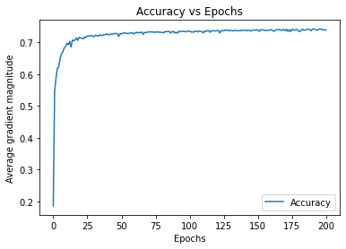

```python
plt.plot(nn_mini.score_, label='Accuracy')
plt.legend()
plt.title('Accuracy vs Epochs')
plt.ylabel('Average gradient magnitude')
plt.xlabel('Epochs')
plt.show()
```

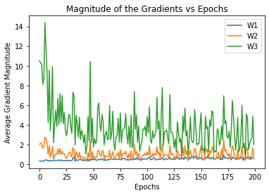

```python
ax = plt.subplot(1,1,1)
for idx in range(len(nn_mini.grad_W_list)):
    plt.plot(abs(nn_mini.grad_W_list[idx]), label='W{}'.format(str(idx+1)))
plt.legend()
plt.title('Magnitude of the Gradients vs Epochs')
plt.ylabel('Average Gradient Magnitude')
plt.xlabel('Epochs')
plt.show()
```

We achieve a three layer model, with 50 units for both first and second layers. Mostly hyperparameters of this model remaining the same as for the two layer models. Except for its `minibatches` was reset to 50. This model get higher accuracy than our optimal two layer model.

From the graph of the magnitudes for each layer versus the number of epochs, we can see that W3 is higher than W2, and W2 is higher than W1. Since the higher gradient means faster learning, we think the layers closer to the output learn better and the layers closer to the input learn more slowly.

### 3.2 Four Layer Multi-layer Perceptron

```python
params = dict(n_hiddens=[50,50,50], # 4 layer
              C=0.1, # tradeoff L2 regularizer
              epochs=200, # iterations
              eta=0.001,  # learning rate
              minibatches= 50, # minibatch size
              shuffle=True,
              random_state=1)

params
```

```
{'n_hiddens': [50, 50, 50],
 'C': 0.1,
 'epochs': 200,
 'eta': 0.001,
 'minibatches': 50,
 'shuffle': True,
 'random_state': 1}
```

```python
nn_mini = MultiLayerPerceptron(**params)

nn_mini.fit(X_train.to_numpy(), y_train.to_numpy(), print_progress=50)
yhat = nn_mini.predict(X_test.to_numpy())
print('Accuracy:',accuracy_score(y_test.to_numpy(),yhat))
```

```
Epoch: 200/200
```

```
Accuracy: 0.6925880088008801
```

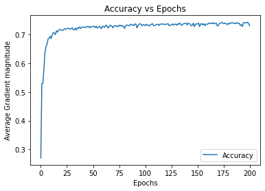

```python
plt.plot(nn_mini.score_, label='Accuracy')
plt.legend()
plt.title('Accuracy vs Epochs')
plt.ylabel('Average Gradient magnitude')
plt.xlabel('Epochs')
plt.show()
```

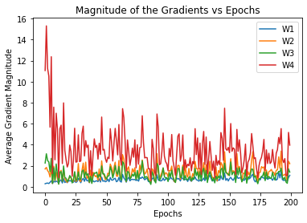

```python
ax = plt.subplot(1,1,1)
for idx in range(len(nn_mini.grad_W_list)):
    plt.plot(abs(nn_mini.grad_W_list[idx]), label='W{}'.format(str(idx+1)))
plt.legend()
plt.title('Magnitude of the Gradients vs Epochs')
plt.ylabel('Average Gradient Magnitude')
plt.xlabel('Epochs')
plt.show()
```

We achieve a four layer model, with 50 units for first, second, and third layers. With all hyperparameters the same as the three layer model, our four layer model achieves a lower accuracy than the three layer model.

Through the above graph, we can see that the relationship between gradient and layer is essentially the same as in the three layer model. W4 is higher than W3 and W2. W3 is higher than W2, while W3 and W2 are close to each other. These are matching our idea that layers closer to the output learn better and layers closer to the input learn more slowly.

### 3.3 Five Layer Multi-layer Perceptron

```python
params = dict(n_hiddens=[50,50,50,50], # 4 layer
              C=0.1, # tradeoff L2 regularizer
              epochs=200, # iterations
              eta=0.001,  # learning rate
              minibatches= 50, # minibatch size
              shuffle=True,
              random_state=1)

params
```

```
{'n_hiddens': [50, 50, 50, 50],
 'C': 0.1,
 'epochs': 200,
 'eta': 0.001,
 'minibatches': 50,
 'shuffle': True,
 'random_state': 1}
```

```python
nn_mini = MultiLayerPerceptron(**params)

nn_mini.fit(X_train.to_numpy(), y_train.to_numpy(), print_progress=50)
yhat = nn_mini.predict(X_test.to_numpy())
print('Accuracy:',accuracy_score(y_test.to_numpy(),yhat))
```

```
Epoch: 200/200
```

```
Accuracy: 0.7222909790979097
```

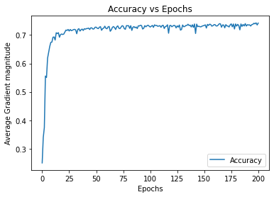

```python
plt.plot(nn_mini.score_, label='Accuracy')
plt.legend()
plt.title('Accuracy vs Epochs')
plt.ylabel('Average Gradient magnitude')
plt.xlabel('Epochs')
plt.show()
```

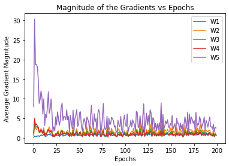

```python
ax = plt.subplot(1,1,1)
for idx in range(len(nn_mini.grad_W_list)):
    plt.plot(abs(nn_mini.grad_W_list[idx]), label='W{}'.format(str(idx+1)))
plt.legend()
plt.title('Magnitude of the Gradients vs Epochs')
plt.ylabel('Average Gradient Magnitude')
plt.xlabel('Epochs')
plt.show()
```

As shown in the figure above, we can see that W4, W3, W2 and W1 seem to differ from our previously mentioned assumption that they should decrease sequentially. For this case, we believe that this may be due to the problem of gradient vanishing.

The problem is that in some cases, the gradient will be vanishingly small, effectively preventing the weight from changing its value. And the use of sigmoid function will caused this problem when developing deep neural networks. Therefore, to avoid this issue we can consider using ReLU instead of sigmoid.

### 3.4 An adaptive learning technique

#### 3.4.1 Implement

```python
import numpy as np
from scipy.special import expit
import sys
import pandas as pd
from sklearn.metrics import accuracy_score
import matplotlib.pyplot as plt
from sklearn.metrics import mean_squared_error
from sklearn.preprocessing import StandardScaler
```

```python
class MultiLayerPerceptron_adaptive(object):

    def __init__(self, n_hiddens=[16, 10], C=0.1, epochs=100, eta=0.001, random_state=1,
                 alpha=0.1, decrease_const=0.0001, shuffle=True, minibatches=1, adaptive_method=0):
        np.random.seed(random_state)
        self.n_hiddens = n_hiddens
        self.l2_C = C
        self.epochs = epochs
        self.eta = eta
        self.alpha = alpha
        self.decrease_const = decrease_const
        self.shuffle = shuffle
        self.minibatches = minibatches
        self.adaptive_method = adaptive_method

    def _initialize_weights(self):

        layers = self.n_hiddens.copy()
        # reduce the final layer magnitude in order to balance the size of the gradients between
        layers.append(self.n_output_)
        W_list = []
        features = self.n_features_
        for idx, size_hidden in enumerate(layers):
            init_bound = 4 * np.sqrt(6. / (size_hidden + features + 1))
            W = np.random.uniform(-init_bound, init_bound, (size_hidden, features + 1))
            W[:, :1] = 0

            features = size_hidden
            W_list.append(W)
        return W_list

    @staticmethod
    def _encode_labels(y):
        """Encode labels into one-hot representation"""
        onehot = pd.get_dummies(y).values.T
        return onehot

    @staticmethod
    def _sigmoid(z):
        """Use scipy.special.expit to avoid overflow"""
        # 1.0 / (1.0 + np.exp(-z))
        return expit(z)

    @staticmethod
    def _add_bias_unit(X, how='column'):
        """Add bias unit (column or row of 1s) to array at index 0"""
        if how == 'column':
            ones = np.ones((X.shape[0], 1))
            X_new = np.hstack((ones, X))
        elif how == 'row':
            ones = np.ones((1, X.shape[1]))
            X_new = np.vstack((ones, X))
        return X_new

    @staticmethod
    def _L2_reg(lambda_, W_list):
        """Compute L2-regularization cost"""
        # only compute for non-bias terms
        weights = 0
        for W in W_list:
            weights += np.mean(W[:, 1:] ** 2)
        return (lambda_ / 2.0) * np.sqrt(weights)

    def _cost(self, output, Y_enc, W_list):
        '''over write cost function'''
        cost = np.mean((Y_enc - output) ** 2)
        L2_term = self._L2_reg(self.l2_C, W_list)
        return cost + L2_term

    def _feedforward(self, X, w_list):
        """Compute feedforward step"""
        A_list = []
        Z_list = []
        for i, W in enumerate(w_list):
            if i == 0:
                A = self._add_bias_unit(X.T, how='row')
            else:
                A = self._sigmoid(Z)
                A = self._add_bias_unit(A, how='row')
            '''print("A.shape:",A.shape)
            print("W.shape:",W.shape)'''
            Z = W @ A
            A_list.append(A)
            Z_list.append(Z)
        A_output = self._sigmoid(Z)
        A_list.append(A_output)
        return A_list, Z_list

    def _get_gradient(self, A_list, Z_list, y, w_list):
        g_list = []
        A_last = A_list[-1]

        # vectorized backpropagation
        V_last = -2 * (y - A_last) * A_last * (1 - A_last)
        i = 1
        length = len(w_list)
        for A, W in zip(A_list[:-1][::-1], w_list[::-1]):
            if i == 1:
                grad = V_last @ A.T
                V = W.T @ V_last
            else:
                grad = V_last[1:, :] @ A.T
                if i != length:
                    V = (W.T @ V_last[1:, :])
            if length - 1 - i >= 0:
                V = A * (1 - A) * V
                V_last = V

            # regularize weights that are not bias terms
            grad[:, 1:] += W[:, 1:] * self.l2_C
            g_list.append(grad)
            i += 1
        return g_list[::-1]

    # Updated here
    def fit(self, X, y, print_progress=False):
        """ Learn weights from training data. With mini-batch"""
        X_data, y_data = X.copy(), y.copy()
        Y_enc = self._encode_labels(y)

        # init weights and setup matrices
        self.n_features_ = X_data.shape[1]
        self.n_output_ = Y_enc.shape[0]
        self.W_list = self._initialize_weights()

        # For adaptive init
        W_pre_list = []
        for W in self.W_list:
            delta_W_pre = np.zeros(W.shape)
            W_pre_list.append(delta_W_pre)

        self.cost_ = []
        self.score_ = []
        self.score_.append(accuracy_score(y_data, self.predict(X_data)))

        len_layers = len(self.n_hiddens)
        self.grad_W_list = []

        rho_W_prev = []
        if (self.adaptive_method == 2):  # AdaM
            for idx in range(len(self.W_list)):
                rho_W_prev.append(np.zeros(self.W_list[idx].shape))

        for i in range(len_layers + 1):
            self.grad_W_list.append(np.zeros(self.epochs, dtype=float))

        for i in range(self.epochs):
            if (self.adaptive_method == 1 or self.adaptive_method == 2):
                eta = self.eta ** (1 + self.decrease_const * i)  # decreasing learning rate
                eta = max(eta, self.eta / 1000)
                # there are many forms of adaptive learning rates out there!

            if print_progress > 0 and (i + 1) % print_progress == 0:
                sys.stderr.write('\rEpoch: %d/%d' % (i + 1, self.epochs))
                sys.stderr.flush()

            if self.shuffle:
                idx_shuffle = np.random.permutation(y_data.shape[0])
                X_data, Y_enc, y_data = X_data[idx_shuffle], Y_enc[:, idx_shuffle], y_data[idx_shuffle]

            mini = np.array_split(range(y_data.shape[0]), self.minibatches)
            mini_cost = []
            for j in mini:
                A_list, Z_list = self._feedforward(X_data[j], self.W_list)
                cost = self._cost(A_list[-1], Y_enc[:, j], self.W_list)
                mini_cost.append(cost)  # this appends cost of mini-batch only

                # compute gradient via backpropagation
                g_list = self._get_gradient(A_list, Z_list, Y_enc[:, j], self.W_list)

                for idx in range(len(self.W_list)):
                    if (self.adaptive_method == 0):
                        self.W_list[idx] -= self.eta * g_list[idx]
                    if (self.adaptive_method == 1 or self.adaptive_method == 2):
                        self.W_list[idx] -= eta * g_list[idx]
                    if (self.adaptive_method == 2):
                        # momentum calculations
                        rho_W = eta * g_list[idx]
                        self.W_list[idx] -= (rho_W + (self.alpha * rho_W_prev[idx]))  # update with momentum
                        rho_W_prev[idx] = rho_W

            self.cost_.append(mini_cost)
            self.score_.append(accuracy_score(y_data, self.predict(X_data)))

            # saving average gradients
            for m in range(len(self.grad_W_list)):
                self.grad_W_list[m][i] += np.mean(abs(g_list[m]))
        return self

    def predict(self, X):
        """Predict class labels"""
        a_list, _ = self._feedforward(X, self.W_list)
        y_pred = np.argmax(a_list[-1], axis=0)
        return y_pred
```

```python
params = dict(n_hiddens=[50,50,50,50], # 4 layer
              C=0.1, # tradeoff L2 regularizer
              epochs=200, # iterations
              eta=0.001,  # learning rate
              minibatches= 50, # minibatch size
              shuffle=True,
              random_state=1,
              adaptive_method = 1
              )

params
```

```
{'n_hiddens': [50, 50, 50, 50],
 'C': 0.1,
 'epochs': 200,
 'eta': 0.001,
 'minibatches': 50,
 'shuffle': True,
 'random_state': 1,
 'adaptive_method': 1}
```

```python
%%time
nn_mini = MultiLayerPerceptron_adaptive(**params)

nn_mini.fit(X_train.to_numpy(), y_train.to_numpy(), print_progress=50)
yhat = nn_mini.predict(X_test.to_numpy())
print('Accuracy:',accuracy_score(y_test.to_numpy(),yhat))
```

```
Epoch: 200/200
```

```
Accuracy: 0.7257288228822882
CPU times: total: 12min 42s
Wall time: 1min 36s
```

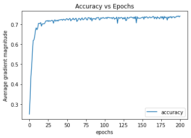

```python
plt.plot(nn_mini.score_, label='accuracy')
plt.legend()
plt.title('Accuracy vs Epochs')
plt.ylabel('Average gradient magnitude')
plt.xlabel('epochs')
plt.show()
```

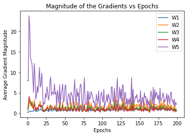

```python
for idx in range(len(nn_mini.grad_W_list)):
    plt.plot(abs(nn_mini.grad_W_list[idx]), label='W{}'.format(str(idx+1)))
plt.legend()
plt.title('Magnitude of the Gradients vs Epochs')
plt.ylabel('Average Gradient Magnitude')
plt.xlabel('Epochs')
plt.show()
```

#### 3.4.2 McNemar Testing for Comparing Performance

To compare the performance of two model based on the same train and test data set. We are going to use the `McNemar Testing`.

Set the Null hypothesis: predictions are not different!

Squared statistic with one DOF:

$𝜒^2 = (abs(B-C)-1)^2 / (B + C)$

| Confidence | 0.90 | 0.95 | 0.99 |
| --- | --- | --- | --- |
| 1 DOF Critical Value | 2.706 | 3.841 | 6.635 |

```python
def create_contingency_McNemar(y_test, model1_pred, model2_pred):

    correct1_correct2 = 0  # model 1 predict correctly, model 2 also predict correctly
    correct1_wrong2 = 0 # model 1 predict correctly, model 2 predict wrong
    wrong1_correct2 = 0
    wrong1_wrong2 = 0
    table = np.zeros([2, 2],dtype = int)

    for i in range(len(y_test)):
        if model1_pred[i] == y_test[i] and model2_pred[i] == y_test[i]:
            correct1_correct2 +=1
        elif model1_pred[i] == y_test[i] and model2_pred[i] != y_test[i]:
            correct1_wrong2 +=1
        elif model1_pred[i] != y_test[i] and model2_pred[i] == y_test[i]:
            wrong1_correct2 +=1
        else:
            wrong1_wrong2 +=1
    table[0][0] = int(correct1_correct2)
    table[0][1] = int(correct1_wrong2)
    table[1][0] = int(wrong1_correct2)
    table[1][1] = int(wrong1_wrong2)

    return table
```

Run the five-layer with and without the adaptive Gradient

```python
%%time
params_nonadaptive = dict(n_hiddens=[50,50,50,50],
              C=0.1, # tradeoff L2 regularizer
              epochs=200, # iterations
              eta=0.001,  # learning rate
              minibatches= 50, # minibatch size
              shuffle=True,
              random_state=1,
              adaptive_method = 0
              )
nn_mini_nonadaptive = MultiLayerPerceptron_adaptive(**params_nonadaptive)

nn_mini_nonadaptive.fit(X_train.to_numpy(), y_train.to_numpy(), print_progress=50)
yhat_nonadaptive = nn_mini_nonadaptive.predict(X_test.to_numpy())
test_acc_nonadaptive = accuracy_score(y_test.to_numpy(),yhat_nonadaptive)
```

```
Epoch: 200/200
```

```
CPU times: total: 12min 30s
Wall time: 1min 34s
```

```python
%%time
params_a_g = dict(n_hiddens=[50,50,50,50],
              C=0.1, # tradeoff L2 regularizer
              epochs=200, # iterations
              eta=0.001,  # learning rate
              minibatches= 50, # minibatch size
              shuffle=True,
              random_state=1,
              adaptive_method = 1
              )
nn_mini_a_g = MultiLayerPerceptron_adaptive(**params_a_g)

nn_mini_a_g.fit(X_train.to_numpy(), y_train.to_numpy(), print_progress=50)
yhat_a_g = nn_mini_a_g.predict(X_test.to_numpy())
test_acc_a_g = accuracy_score(y_test.to_numpy(),yhat_a_g)
```

```
Epoch: 200/200
```

```
CPU times: total: 12min 14s
Wall time: 1min 32s
```

```python
from statsmodels.stats.contingency_tables import mcnemar

ytrue = y_test.to_numpy()
ypred1 = yhat_nonadaptive
ypred2 = yhat_a_g

print('five-layer non-Adaptive Acc:\t', test_acc_nonadaptive)
print('five-layer Adaptive-Gradient Acc:\t', test_acc_a_g)
print('---------------------------------------------------')

print('five-layer non-Adaptive & five-layer Adaptive-Gradient')

print('contingency_tables:')
temp_table = create_contingency_McNemar(ytrue, ypred1, ypred2)
print(temp_table)
print('caculate the McNemar')
result = mcnemar(temp_table, exact=True)
print(result)
if result.pvalue < 0.05:
    print('Reject the Null hypothesis : they have Different proportions of errors, we can say the models\' performance are different based on the evidence')
else:
    print('Take the Null hypothesis: Base on (alpha <0.05), we cannot say the models\' performance are different')
```

```
five-layer non-Adaptive Acc:	 0.7222909790979097
five-layer Adaptive-Gradient Acc:	 0.7257288228822882
---------------------------------------------------
five-layer non-Adaptive & five-layer Adaptive-Gradient
contingency_tables:
[[10362   143]
 [  193  3846]]
caculate the McNemar
pvalue      0.007422389087167445
statistic   143.0
Reject the Null hypothesis : they have Different proportions of errors, we can say the models' performance are different based on the evidence
```

## 4. Exceptional Work (AdaM)

```python
params_a_m = dict(n_hiddens=[50,50,50,50], # 4 layer
              C=0.1, # tradeoff L2 regularizer
              epochs=200, # iterations
              eta=0.001,  # learning rate
              minibatches= 50, # minibatch size
              shuffle=True,
              random_state=1,
              adaptive_method = 2
              )

params_a_m
```

```
{'n_hiddens': [50, 50, 50, 50],
 'C': 0.1,
 'epochs': 200,
 'eta': 0.001,
 'minibatches': 50,
 'shuffle': True,
 'random_state': 1,
 'adaptive_method': 2}
```

```python
%%time

nn_mini_a_m = MultiLayerPerceptron_adaptive(**params_a_m)

nn_mini_a_m.fit(X_train.to_numpy(), y_train.to_numpy(), print_progress=50)
yhat_a_m = nn_mini_a_m.predict(X_test.to_numpy())
test_acc_a_m = accuracy_score(y_test.to_numpy(),yhat_a_m)
print('Accuracy:',test_acc_a_m)
```

```
Epoch: 200/200
```

```
Accuracy: 0.7171342134213421
CPU times: total: 12min 32s
Wall time: 1min 34s
```

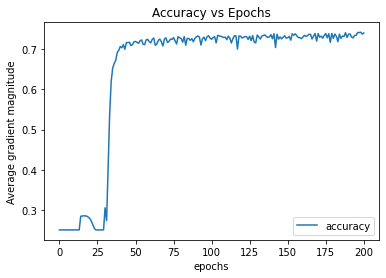

```python
plt.plot(nn_mini_a_m.score_, label='accuracy')
plt.legend()
plt.title('Accuracy vs Epochs')
plt.ylabel('Average gradient magnitude')
plt.xlabel('epochs')
plt.show()
```

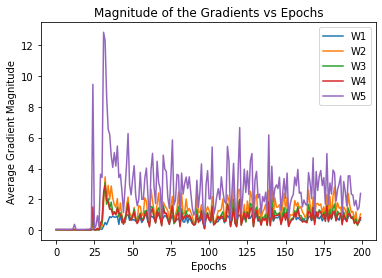

```python
for idx in range(len(nn_mini_a_m.grad_W_list)):
    plt.plot(abs(nn_mini_a_m.grad_W_list[idx]), label='W{}'.format(str(idx+1)))
plt.legend()
plt.title('Magnitude of the Gradients vs Epochs')
plt.ylabel('Average Gradient Magnitude')
plt.xlabel('Epochs')
plt.show()
```

```python
from statsmodels.stats.contingency_tables import mcnemar

ytrue = y_test.to_numpy()
ypred1 = yhat_nonadaptive
ypred2 = yhat_a_g
ypred3 = yhat_a_m

print('five-layer non-Adaptive Acc:\t', test_acc_nonadaptive)
print('five-layer Adaptive-Gradient Acc:\t', test_acc_a_g)
print('five-layer Adaptive-Momentum Acc:\t', test_acc_a_m)
print('---------------------------------------------------')
# print('contingency_tables:')
print('five-layer non-Adaptive & five-layer Adaptive-Gradient')
print('contingency_tables:')

temp_table = create_contingency_McNemar(ytrue, ypred1, ypred2)
print(temp_table)
print('caculate the McNemar:')
result_1 = mcnemar(temp_table, exact=True)
print(result_1)
if result.pvalue < 0.05:
    print('Reject the Null hypothesis : they have Different proportions of errors, we can say the models\' performance are different based on the evidence')
else:
    print('Take the Null hypothesis: Base on (alpha <0.05), we cannot say the models\' performance are different')
print('---------------------------------------------------')


print('five-layer non-Adaptive & five-layer Adaptive-Momentum')
print('contingency_tables:')

temp_table_2 = create_contingency_McNemar(ytrue, ypred1, ypred3)
print(temp_table_2)
print('caculate the McNemar:')
result_2 = mcnemar(temp_table_2, exact=True)
print(result_2)
if result_2.pvalue < 0.05:
    print('Reject the Null hypothesis : they have Different proportions of errors, we can say the models\' performance are different based on the evidence')
else:
    print('Take the Null hypothesis: Base on (alpha <0.05), we cannot say the models\' performance are different')
print('---------------------------------------------------')


print('five-layer Adaptive-Gradient & five-layer Adaptive-Momentum')
print('contingency_tables:')

temp_table_3 = create_contingency_McNemar(ytrue, ypred2, ypred3)
print(temp_table_3)
print('caculate the McNemar:')
result_3 = mcnemar(temp_table_3, exact=True)
print(result_3)
if result_3.pvalue < 0.05:
    print('Reject the Null hypothesis : they have Different proportions of errors, we can say the models\' performance are different based on the evidence')
else:
    print('Take the Null hypothesis: Base on (alpha <0.05), we cannot say the models\' performance are different')

print('---------------------------------------------------')
```

```
five-layer non-Adaptive Acc:	 0.7222909790979097
five-layer Adaptive-Gradient Acc:	 0.7257288228822882
five-layer Adaptive-Momentum Acc:	 0.7171342134213421
---------------------------------------------------
five-layer non-Adaptive & five-layer Adaptive-Gradient
contingency_tables:
[[10362   143]
 [  193  3846]]
caculate the McNemar:
pvalue      0.007422389087167445
statistic   143.0
Reject the Null hypothesis : they have Different proportions of errors, we can say the models' performance are different based on the evidence
---------------------------------------------------
five-layer non-Adaptive & five-layer Adaptive-Momentum
contingency_tables:
[[10150   355]
 [  280  3759]]
caculate the McNemar:
pvalue      0.003286864755918265
statistic   280.0
Reject the Null hypothesis : they have Different proportions of errors, we can say the models' performance are different based on the evidence
---------------------------------------------------
five-layer Adaptive-Gradient & five-layer Adaptive-Momentum
contingency_tables:
[[10107   448]
 [  323  3666]]
caculate the McNemar:
pvalue      7.64181636978989e-06
statistic   323.0
Reject the Null hypothesis : they have Different proportions of errors, we can say the models' performance are different based on the evidence
---------------------------------------------------
```

Me can say the AdaM model is have different performance compare to previous model. And since we are using the same train and test dataset, we can simply use the cccuracy to evaluate the model.

```
params_a_m = dict(n_hiddens=[50,50,50,50], # 4 layer
              C=0.1, # tradeoff L2 regularizer
              epochs=200, # iterations
              eta=0.001,  # learning rate
              minibatches= 50, # minibatch size
              shuffle=True,
              random_state=1,
              adaptive_method = 2
              )
```

```python
amethod = ['non-adaptive 5 layer model','AdaGrad 5 layer model','AdaM 5 layer model']
aresult = [test_acc_nonadaptive,test_acc_a_g,test_acc_a_m]
df_result_table = pd.DataFrame(list(zip(amethod,aresult)),columns=['Model name', 'Acc'])
df_result_table
```

|  | Model name | Acc |
| --- | --- | --- |
| 0 | non-adaptive 5 layer model | 0.722291 |
| 1 | AdaGrad 5 layer model | 0.725729 |
| 2 | AdaM 5 layer model | 0.717134 |

```python
print('The highest acc model here:')
print(amethod[aresult.index(max(aresult))])
```

[output not shown]